# BCC125_sea_lamprey_scRNA

Stephanie Hickey

2026-06-22

#### Lab: Weiming Li

#### Project: BCC125_sea_lamprey_scRNA

#### Sample: UND1_C00004336

```r
library(tidyverse)
library(Matrix)
library(SingleCellExperiment)
library(monocle3)
library(DropletUtils)
library(scater)
library(ape)
source(paste0(params$project_dir, "/src/scRNA_seq_functions.R"))
```

```r
results_dir = paste0(params$project_dir, "/results/UND1_QC")
# results_dir = "/mnt/ufs18/rs-013/bioinformaticsCore/projects/chong_davidson/BCC125_sea_lamprey_scRNA/results/UND1_QC"
data_dir = paste0(params$project_dir, "/data")
# data_dir = "/mnt/ufs18/rs-013/bioinformaticsCore/projects/chong_davidson/BCC125_sea_lamprey_scRNA/data"
```

```r
sampleID = params$sampleID
mat = readMM(paste0(data_dir, "/", sampleID, "/raw_matrix/matrix.mtx.gz"))
barcodes = read.delim(paste0(data_dir, "/", sampleID, "/raw_matrix/barcodes.tsv.gz"), header=F)
barcodes$V1 = paste0(sampleID, "_", barcodes$V1)

genes = read.delim(paste0(data_dir,"/", sampleID, "/raw_matrix/features.tsv.gz"), header=F)

rownames(mat) = genes$V1
colnames(mat) = barcodes$V1
```

```r
sce <- SingleCellExperiment(assays = list(counts = mat))
```

## Detect empty droplets with `DropletUtils`

```r
# Set a seed. This can be any number. Using the same number every time ensures that a sequence of random numbers generated is the same every time you run your code.
set.seed(100)

# set `by.rank` to the max number of cells you expect
e.out <- emptyDrops(counts(sce),
                    by.rank = as.numeric(params$expected_cells))

# add barcodes to a column
e.out$barcode = rownames(e.out)

# make a vector of significant barcodes
# use a false discovery rate (FDR) of 0.1%,
# meaning that no more than 0.1% of our called
# barcodes should be empty droplets on average.
sig_barcodes <-
  as_tibble(e.out) %>%
  filter(FDR < .001) %>%
  pull(barcode)
```

Empty droplets often contain RNA from the ambient solution, resulting in non-zero counts after debarcoding. The `emptyDrops` function is designed to distinguish between empty droplets and cells. It does so by testing each barcode’s expression profile for significant deviation from the ambient profile. Using this method, 18442 barcodes represent cells.

Below is a barcode rank plot, or knee plot, which shows the (log-)total UMI count for each barcode on the y-axis and the (log-)rank on the x-axis. The plot resembles a curve with a sharp “knee” or “elbow.” Cells with high RNA content (likely real biological cells), are on the left side of the plot. Low-RNA-content cells (likely empty droplets or low-quality cells) are on the right side. The “knee” or transition point marks the threshold between high-quality cells and low-quality or empty droplets.

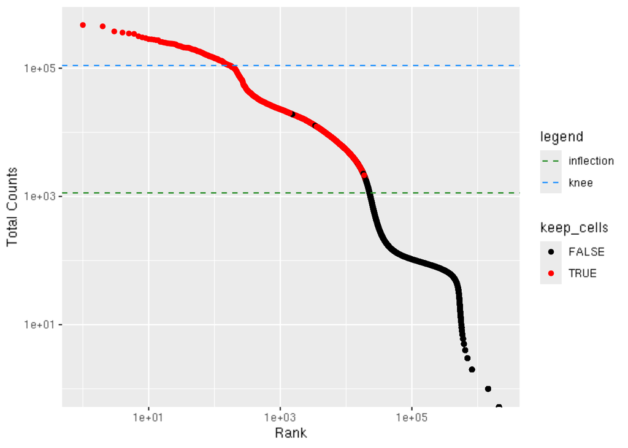

```r
br.out <- barcodeRanks(counts(sce))

# make the rownames a column
br.out$barcodes <- rownames(br.out)

br.df =
  as.data.frame(br.out) %>%
  mutate(keep_cells = case_when(
   barcodes %in% sig_barcodes ~ "TRUE",
   !barcodes %in% sig_barcodes ~ "FALSE"
  ))

# Making the knee plot.
ggplot(br.df, aes(x=rank, y=total)) +
  geom_point(aes(color = keep_cells)) +
  scale_colour_manual(values = c("black","red")) +
  geom_hline(aes(yintercept=metadata(br.out)$knee,
             linetype="knee"),
             color = "dodgerblue") +
  geom_hline(aes(yintercept=metadata(br.out)$inflection,
             linetype="inflection"),
             color = "forestgreen") +
  scale_linetype_manual(name = "legend",
                        values = c(2, 2),
                        guide = guide_legend(override.aes = list(color = c("forestgreen", "dodgerblue")))) +
  scale_x_continuous(trans='log10') +
  scale_y_continuous(trans='log10') +
  xlab("Rank") +
  ylab("Total Counts")
```

```r
ggsave(file = paste0(results_dir,"/", sampleID, "_kneeplot.png"))
sce <- sce[,sig_barcodes]
```

## Identifying low quality cells

Common metrics include for identifying low quality cells include:

- Total counts
- Number of expressed features (genes)
- Proportion of reads mapped to genes in the mitochondrial genome

For each cell, we calculate these QC metrics using the `perCellQCMetrics()` function from the `scater` package.

```r
# Identifying the mitochondrial transcripts in our SingleCellExperiment.

# mouse mito genes start with "mt"
# human is "MT"
# change for different species
# this is a numeric vector of row numbers
# corresponding to mito genes
# NC_001626.1
all_genes = read.delim("/mnt/research/bioinformaticsCore/shared/Genomes/Petromyzon_marinus/GCF_010993605.1_kPetMar1.pri_genes.txt", header=F)

mito_genes =
  all_genes %>%
  filter(V1 == "NC_001626.1") %>%
  pull(V6)

mito_genes = gsub("gene ", "", mito_genes)
is.mito = which(rownames(sce) %in% mito_genes)

# get the per cell stats
stats <- perCellQCMetrics(sce,
                          subsets=list(Mito=is.mito))
```

### Summarize the stats

The total counts in each cell:

```r
summary(stats$sum)
```

```
##    Min. 1st Qu.  Median    Mean 3rd Qu.    Max.
##    1796    3569    5715    9906   10215  471718
```

The number of genes with at least one count in each cell:

```r
summary(stats$detected)
```

```
##    Min. 1st Qu.  Median    Mean 3rd Qu.    Max.
##     321     977    1367    1663    1954   11608
```

These are the genes on the mitochondrial chromosome, NC_001626.1.

```r
mito_genes
```

```
##  [1] "CYTB" "ND1"  "ND2"  "COX1" "COX2" "ATP8" "ATP6" "COX3" "ND3"  "ND4L"
## [11] "ND4"  "ND5"  "ND6"
```

The percent of counts that come from mitochondria genes:

```r
summary(stats$subsets_Mito_percent)
```

```
##    Min. 1st Qu.  Median    Mean 3rd Qu.    Max.
##  0.0000  0.9095  1.3673  1.7213  1.9984 25.6841
```

Normally, I would filter out cells with high percent mitochondria, but female germ cells likely have biologically high percent mitochondria. So I will cluster first and attempt to identify female germ cells before performing any QC filtering.

```r
counts = counts(sce)
cds <- new_cell_data_set(counts,
                         cell_metadata = stats)

cds <- preprocess_cds(cds, num_dim = 100)

cds <- reduce_dimension(cds)
```

## Cluster the cells and check for enrichment of known cell-type markers

The plot below is a UMAP dimentionality reduction plot where each cell is a dot colored by its cluster membership.

```r
cds <- cluster_cells(cds, resolution=1e-5)
plot_cells(cds)
ggsave(file = paste0(results_dir, "/", sampleID, "_cluster_UMAP.png"))

not_mito = genes$V1[!genes$V1 %in% mito_genes]
cds_nomito = cds[not_mito,]
```

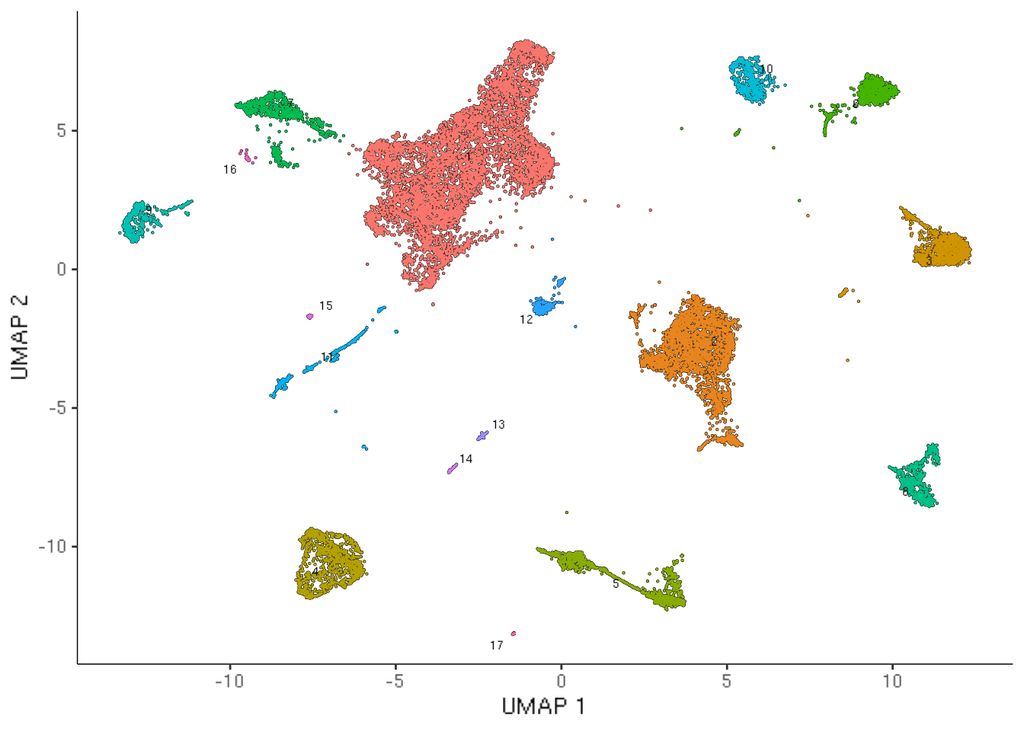

```r
plot_cells(cds)
```

```r
ggsave(file = paste0(results_dir, "/", sampleID, "_cluster_UMAP.png"))
```

This table contains the top ~100 cluster enriched genes for each cluster after removing mitochondria genes. It is saved in UND1_C00004336_cluster_marker_genes.csv. The markers can help us map a cluster to a cell type.

**Column descriptions**

- `gene_id` vector of gene names
- `cell_group` character vector of the cell group to which the cell belongs
- `marker_score` numeric vector of marker scores as the fraction expressing scaled by the specificity. The value ranges from 0 to 1.
- `mean_expression` numeric vector of mean normalized expression of the gene in the cell group
- `fraction_expressing` numeric vector of fraction of cells expressing the gene within the cell group
- `specificity` numeric vector of a measure of how specific the gene’s expression is to the cell group based on the Jensen-Shannon divergence. The value ranges from 0 to 1.
- `pseudo_R2` numeric vector of pseudo R-squared values, a measure of how well the gene expression model fits the categorical data relative to the null model. The value ranges from 0 to 1.
- `marker_test_p_value` numeric vector of likelihood ratio p-values
- `marker_test_q_value` numeric vector of likelihood ratio q-values

```r
marker_test_res <- top_markers(cds_nomito,
                               genes_to_test_per_group = 100,
                               group_cells_by="cluster", cores=8)

write.csv(marker_test_res, file = paste0(results_dir, "/", sampleID, "_cluster_marker_genes.csv"), row.names = FALSE)
```

```r
library(DT)
datatable(marker_test_res, filter = "top", rownames= FALSE)
```

| gene_id | cell_group | marker_score | mean_expression | fraction_expressing | specificity | pseudo_R2 | marker_test_p_value | marker_test_q_value |
| --- | --- | --- | --- | --- | --- | --- | --- | --- |
| LOC116940268 | 1 | 0.12199635752848 | 2.56002304033706 | 0.733019781435883 | 0.16642982988741 | 0.112028176008849 | 0 | 0 |
| LOC116940358 | 1 | 0.118247113499234 | 0.780517604468453 | 0.372942315672984 | 0.317065424141677 | 0.162626354697005 | 0 | 0 |
| LOC116944693 | 1 | 0.135107859606979 | 8.21568391279997 | 0.974823627057684 | 0.13859723529145 | 0.230306362169693 | 0 | 0 |
| CTNNB1 | 1 | 0.18240625590037 | 3.14386428689932 | 0.89223959053811 | 0.204436406806787 | 0.37501806023634 | 0 | 0 |
| LOC116945884 | 1 | 0.163147105866024 | 6.34842354119135 | 0.729008161571448 | 0.223793250152844 | 0.278207027395439 | 0 | 0 |
| LOC116947065 | 1 | 0.127185954053655 | 3.5851940578565 | 0.902614469497856 | 0.140908392621284 | 0.142977563133928 | 0 | 0 |
| LOC116948243 | 1 | 0.122403225848886 | 10.4610076914501 | 0.978973578641583 | 0.125032205689077 | 0.108739000010432 | 0 | 0 |
| SRI | 1 | 0.12440764639745 | 5.35581731616148 | 0.954627196016047 | 0.130320660166232 | 0.167225608897912 | 0 | 0 |
| LOC116950144 | 1 | 0.171885992250462 | 29.6626956016341 | 0.986305159773136 | 0.174272628047488 | 0.256666613579913 | 0 | 0 |
| CSRP2 | 1 | 0.125981632024677 | 1.05450259161706 | 0.483746022963065 | 0.260429287362422 | 0.1666052247838 | 0 | 0 |

[output cut: 1690 more lines]

We’ll check for the significance of the overlap between the top 100 cluster enriched genes and the supplied known cell-type markers. In the plot below, the rows represent cell types with know marker genes, and the columns represent the cell clusters. The number in each box is the number of genes shared between the top 100 cluster enriched genes for the specified clusters and the specified known cell-type markers. Each box is colored by the significance of the overlap ($-log10(FDR)$). Significant overlaps may signify that the cells in the cluster belong to the specified cell type. In this case, female germ cells may be represented by cluster 5 and/or 7.

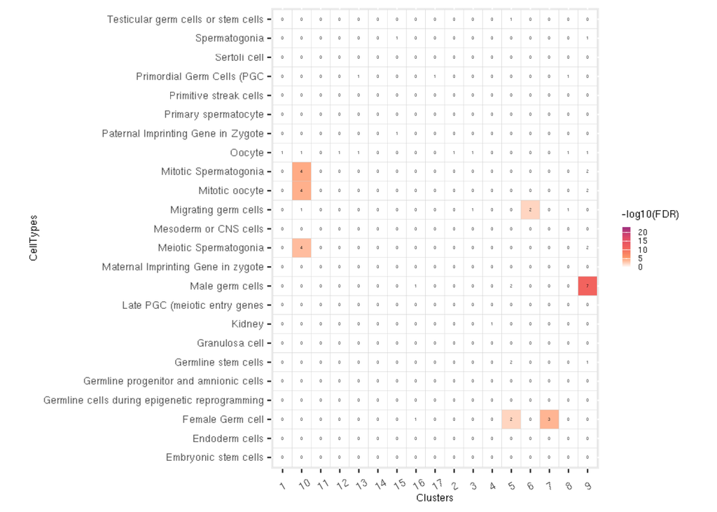

```r
# load known marker genes
library(readr)
chung_davidson_cell_type_markers <- read_csv(paste0(data_dir, "/chung_davidson_cell_type_markers.csv"))
chung_davidson_cell_type_markers =
  chung_davidson_cell_type_markers %>%
  select(-GeneName)

marker_test_genes =
  marker_test_res %>%
  select(gene_id, cell_group)

cluster_ol =  phyperOverlapSets(chung_davidson_cell_type_markers,
                                marker_test_genes, nrow(genes))

write.csv(cluster_ol$intersecting.genes, file = paste0(results_dir, "/", sampleID, "_marker_gene_overlaps.csv"), row.names = FALSE)

scores = cluster_ol$pval.scores

scores =
  scores %>%
  rename(Group1 = "CellTypes",
         Group2 = "Clusters") %>%
  group_by(CellTypes) %>%
    mutate(FDR = p.adjust(Pval, "BH"))

scores$FDR[scores$FDR > .01] = 1

plot1 =
    ggplot(scores,
           aes(Clusters, CellTypes)) +
           geom_tile(aes(fill = -log10(FDR)),
                     color = "light gray") +
        #Creating legend
        guides(fill=guide_colorbar(title = "-log10(FDR)",
                                   barheight = 10,
                                   barwidth = 2,
                                   default.unit = "mm")) +
        #Creating color range
        scale_fill_gradientn(colors=c("white",
                                      "#fd9668",
                                      "#f1605d",
                                      "#de4968",
                                      "#9e2f7f"),
                             guide="colorbar",
                             limits = c(0, 23)) +
        #Rotating labels
        theme(axis.text.x = element_text(angle = 30,
                                         hjust = 0,vjust=-0.05),
              ) +
        theme(text = element_text(size = 7),
              axis.text = element_text(size = 7)) +
        geom_text(aes(label = nSharedGenes), size = 1) +
        coord_fixed()

plot1
```

```r
ggsave(plot1, file = paste0(results_dir, "/", sampleID, "_overlap_heatmap.png"))
```

```r
datatable(cluster_ol$intersecting.genes, filter = "top")
```

|  | Group1 | Group2 | SharedGene |
| --- | --- | --- | --- |
| Maternal Imprinting Gene in zygote.1 | Maternal Imprinting Gene in zygote | 1 | none |
| Maternal Imprinting Gene in zygote.10 | Maternal Imprinting Gene in zygote | 10 | none |
| Maternal Imprinting Gene in zygote.11 | Maternal Imprinting Gene in zygote | 11 | none |
| Maternal Imprinting Gene in zygote.12 | Maternal Imprinting Gene in zygote | 12 | none |
| Maternal Imprinting Gene in zygote.13 | Maternal Imprinting Gene in zygote | 13 | none |
| Maternal Imprinting Gene in zygote.14 | Maternal Imprinting Gene in zygote | 14 | none |
| Maternal Imprinting Gene in zygote.15 | Maternal Imprinting Gene in zygote | 15 | none |
| Maternal Imprinting Gene in zygote.16 | Maternal Imprinting Gene in zygote | 16 | none |
| Maternal Imprinting Gene in zygote.17 | Maternal Imprinting Gene in zygote | 17 | none |
| Maternal Imprinting Gene in zygote.2 | Maternal Imprinting Gene in zygote | 2 | none |

[output cut: 422 more lines]

## Plot percent mitochodria reads per cell

Shown here is a UMAP dimentionality reduction plot where each cell is a dot colored by the percent mitochondria genes detected in the cell.

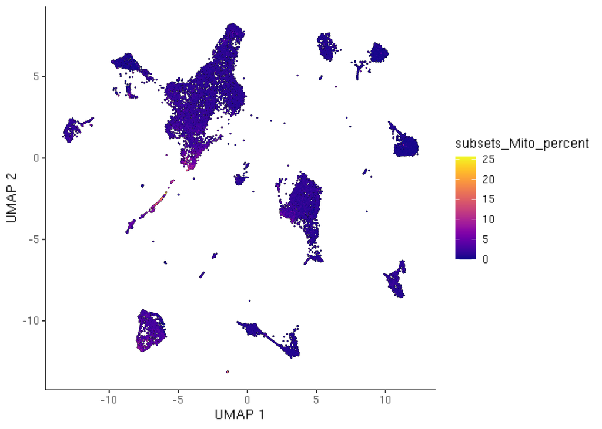

```r
plot_cells(cds, color_cells_by="subsets_Mito_percent")
```

```r
ggsave(file = paste0(results_dir, "/", sampleID, "_cluster_UMAP_percent_mito.png"))
```

## Plot Mitochondria reads percent per cluster

```r
high.mito <- isOutlier(stats$subsets_Mito_percent, type="higher")
```

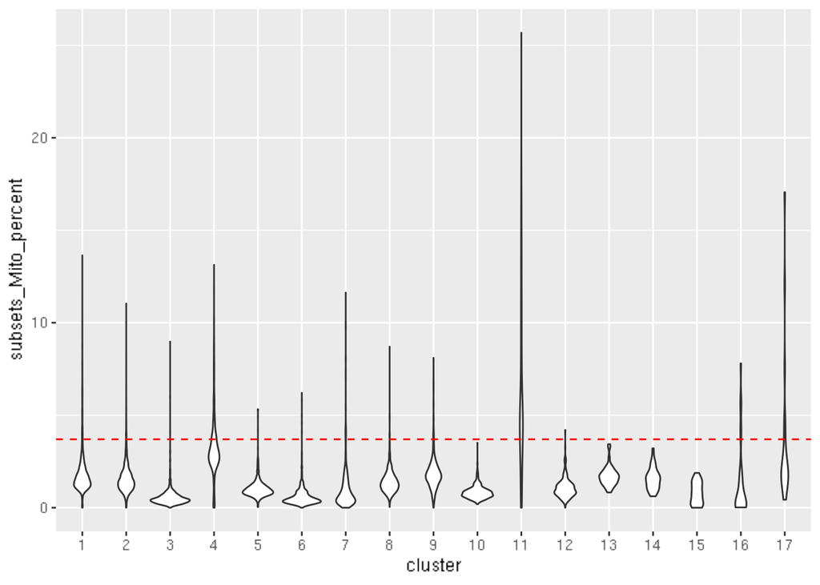

```r
colData(cds)$cluster = clusters(cds)
colData(cds)$discard = high.mito
saveRDS(cds, file = paste0(data_dir, "/", sampleID, "_cds.Rds"))

mito_vln =
  ggplot(colData(cds), aes(y = subsets_Mito_percent, x = cluster)) +
  geom_violin() +
  geom_hline(yintercept=as.numeric(attr(high.mito, "thresholds")[2]),
             linetype="dashed", color = "red")

mito_vln
```

```r
ggsave(mito_vln, file = paste0(results_dir, "/", sampleID, "_percent_mito_vln.png"))
```

Shown here is a UMAP dimentionality reduction plot where each cell is a dot colored by whether or not the cell will be discarded.

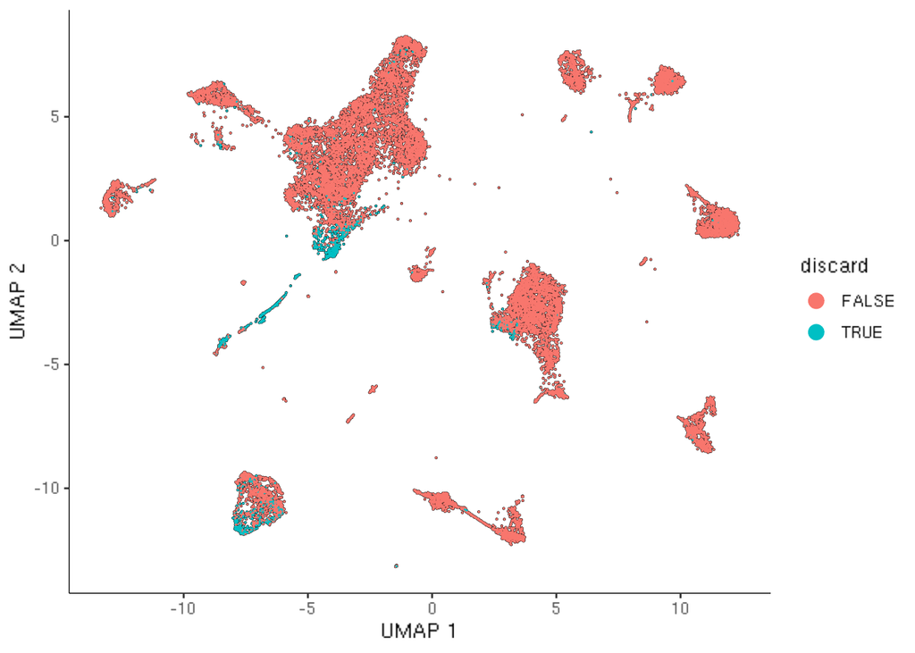

```r
plot_cells(cds, color_cells_by="discard")
```

```r
ggsave(file = paste0(results_dir, "/", sampleID, "_high_mito_UMAP.png"))
```

## Remove high mito cells and re-cluster

```r
colData(cds)$barcode = rownames(colData(cds))
colData_df = as.data.frame(colData(cds))

keep_cells =
  colData_df %>%
  filter(discard == FALSE) %>%
  pull(barcode)

cds = cds[,keep_cells]
cds <- preprocess_cds(cds, num_dim = 100)
cds <- reduce_dimension(cds)
cds <- cluster_cells(cds, resolution=1e-5)
saveRDS(cds, file = paste0(data_dir, "/", sampleID, "_cds_mito_filter.Rds"))

plot_cells(cds)
ggsave(file = paste0(results_dir, "/", sampleID, "_cluster_mito_filtered_UMAP.png"))
```

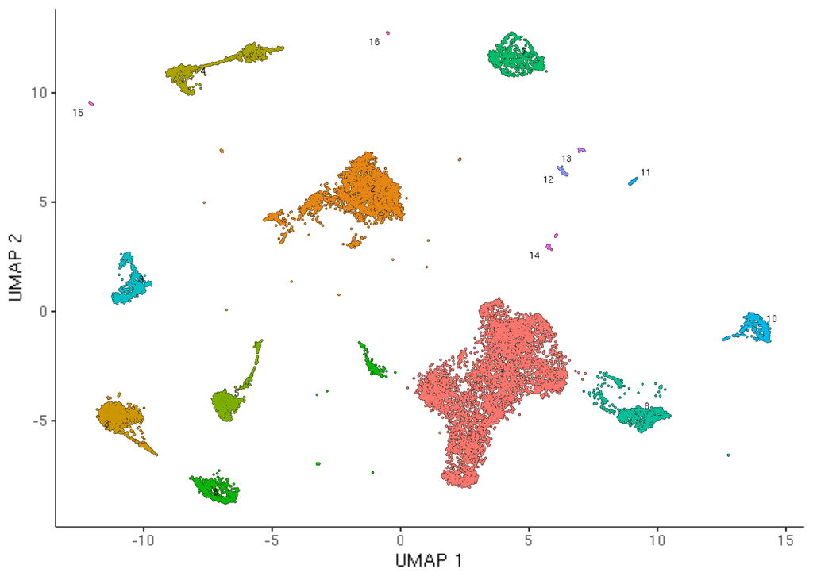

```r
cds <- readRDS(paste0(data_dir, "/", sampleID, "/", sampleID, "_cds_mito_filter.Rds"))
plot_cells(cds)
```

```r
ggsave(file = paste0(results_dir, "/", sampleID, "_cluster_mito_filtered_UMAP.png"))
```

## Check for enrichment of known cell-type markers

This table contains the top ~100 cluster enriched genes for each cluster after removing mitochondria genes. It is saved in UND1_C00004336_cluster_marker_genes_mito_filtered.csv. The markers can help us map a cluster to a cell type.

**Column descriptions**

- `gene_id` vector of gene names
- `cell_group` character vector of the cell group to which the cell belongs
- `marker_score` numeric vector of marker scores as the fraction expressing scaled by the specificity. The value ranges from 0 to 1.
- `mean_expression` numeric vector of mean normalized expression of the gene in the cell group
- `fraction_expressing` numeric vector of fraction of cells expressing the gene within the cell group
- `specificity` numeric vector of a measure of how specific the gene’s expression is to the cell group based on the Jensen-Shannon divergence. The value ranges from 0 to 1.
- `pseudo_R2` numeric vector of pseudo R-squared values, a measure of how well the gene expression model fits the categorical data relative to the null model. The value ranges from 0 to 1.
- `marker_test_p_value` numeric vector of likelihood ratio p-values
- `marker_test_q_value` numeric vector of likelihood ratio q-values

```r
marker_test_res <- top_markers(cds,
                               genes_to_test_per_group = 100,
                               group_cells_by="cluster", cores=8)

write.csv(marker_test_res, file = paste0(results_dir, "/", sampleID, "_cluster_marker_genes_mito_filtered.csv"), row.names = FALSE)
```

```r
library(DT)
datatable(marker_test_res, filter = "top")
```

|  | gene_id | cell_group | marker_score | mean_expression | fraction_expressing | specificity | pseudo_R2 | marker_test_p_value | marker_test_q_value |
| --- | --- | --- | --- | --- | --- | --- | --- | --- | --- |
| 1 | LOC116940914 | 1 | 0.12031404049349 | 1.53482095478327 | 0.625815056312982 | 0.192251751184009 | 0.132717543759742 | 0 | 0 |
| 2 | LOC116943276 | 1 | 0.12770340006971 | 0.603463787279807 | 0.249555423829283 | 0.511723600754395 | 0.160403034629136 | 0 | 0 |
| 3 | LOC116939582 | 1 | 0.125569467347347 | 1.44848523819531 | 0.408713692946058 | 0.307230879499601 | 0.141883434419069 | 0 | 0 |
| 4 | LOC116940268 | 1 | 0.126210071695403 | 2.56317170722485 | 0.746591582691168 | 0.169048345335565 | 0.117619109261956 | 0 | 0 |
| 5 | LOC116940358 | 1 | 0.124078323436831 | 0.72909821361713 | 0.374629519857736 | 0.331202739933441 | 0.160937331195131 | 0 | 0 |
| 6 | LOC116944693 | 1 | 0.145175276983045 | 8.45133685304974 | 0.984588026081802 | 0.147447737670318 | 0.262335324945161 | 0 | 0 |
| 7 | CTNNB1 | 1 | 0.184842568954868 | 3.16028878280721 | 0.906046235921755 | 0.204010084283194 | 0.385079870596241 | 0 | 0 |
| 8 | LOC116945884 | 1 | 0.150434731281384 | 6.3069379932986 | 0.727030231179609 | 0.206916748203584 | 0.290853140423755 | 0 | 0 |
| 9 | LOC116947065 | 1 | 0.132115889901907 | 3.68007655754874 | 0.924718435091879 | 0.14287147837469 | 0.168247048508367 | 0 | 0 |
| 10 | LOC116948243 | 1 | 0.122792147455407 | 10.554434474539 | 0.985477178423237 | 0.124601715944223 | 0.125755469010525 | 0 | 0 |

[output cut: 1590 more lines]

Again, we’ll check for the significance of the overlap between the top 100 cluster enriched genes and the supplied known cell-type markers. In the plot below, the rows represent cell types with know marker genes, and the columns represent the cell clusters. The number in each box is the number of genes shared between the top 100 cluster enriched genes for the specified clusters and the specified known cell-type markers. Each box is colored by the significance of the overlap ($-log10(FDR)$).

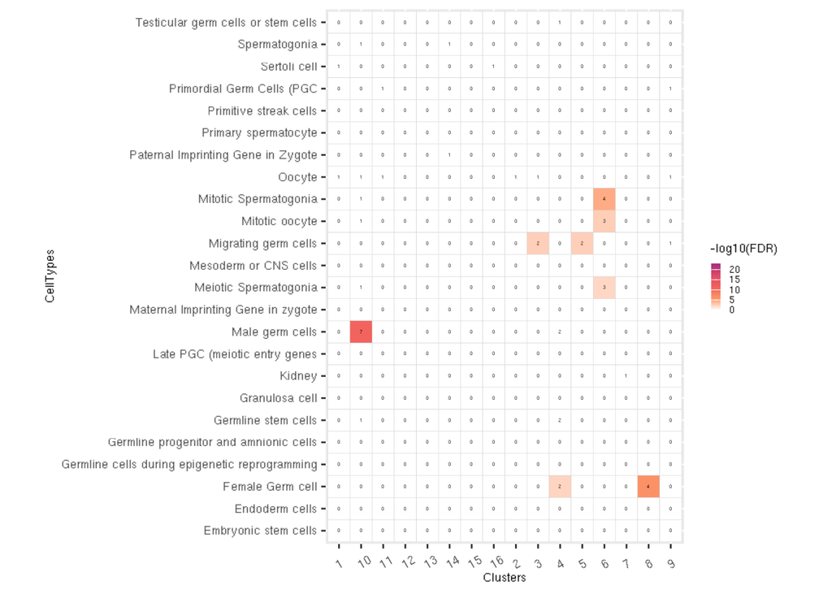

```r
marker_test_genes =
  marker_test_res %>%
  select(gene_id, cell_group)

cluster_ol =  phyperOverlapSets(chung_davidson_cell_type_markers,
                                marker_test_genes, nrow(genes))

write.csv(cluster_ol$intersecting.genes, file = paste0(results_dir, "/", sampleID, "_marker_gene_overlaps_mito_filtered.csv"), row.names = FALSE)

scores = cluster_ol$pval.scores

scores =
  scores %>%
  rename(Group1 = "CellTypes",
         Group2 = "Clusters") %>%
  group_by(CellTypes) %>%
    mutate(FDR = p.adjust(Pval, "BH"))

scores$FDR[scores$FDR > .01] = 1

plot1 =
    ggplot(scores,
           aes(Clusters, CellTypes)) +
           geom_tile(aes(fill = -log10(FDR)),
                     color = "light gray") +
        #Creating legend
        guides(fill=guide_colorbar(title = "-log10(FDR)",
                                   barheight = 10,
                                   barwidth = 2,
                                   default.unit = "mm")) +
        #Creating color range
        scale_fill_gradientn(colors=c("white",
                                      "#fd9668",
                                      "#f1605d",
                                      "#de4968",
                                      "#9e2f7f"),
                             guide="colorbar",
                             limits = c(0, 23)) +
        #Rotating labels
        theme(axis.text.x = element_text(angle = 30,
                                         hjust = 0,vjust=-0.05),
              ) +
        theme(text = element_text(size = 7),
              axis.text = element_text(size = 7)) +
        geom_text(aes(label = nSharedGenes), size = 1) +
        coord_fixed()

plot1
```

```r
ggsave(plot1, file = paste0(results_dir, "/", sampleID, "_overlap_heatmap_mito_filtered.png"))
```

A table with the overlapping genes is shown below. Filtering for `Group1` = “Female Germ Cell” and `Group2` = “8” will show the genes shared between those groups.

```r
datatable(cluster_ol$intersecting.genes, filter = "top", rownames = FALSE)
```

| Group1 | Group2 | SharedGene |
| --- | --- | --- |
| Maternal Imprinting Gene in zygote | 1 | none |
| Maternal Imprinting Gene in zygote | 10 | none |
| Maternal Imprinting Gene in zygote | 11 | none |
| Maternal Imprinting Gene in zygote | 12 | none |
| Maternal Imprinting Gene in zygote | 13 | none |
| Maternal Imprinting Gene in zygote | 14 | none |
| Maternal Imprinting Gene in zygote | 15 | none |
| Maternal Imprinting Gene in zygote | 16 | none |
| Maternal Imprinting Gene in zygote | 2 | none |
| Maternal Imprinting Gene in zygote | 3 | none |

[output cut: 395 more lines]